# EDA

## Preprocessing

### Definitions

`Corpus` = All reviews on GlassDoor for five major banks

`Text` = Reviews for each bank –> Used this also as the `Document`

`Tokens` = Words in each review

### Data structure

| page | review_id | company | review_title | employee_role | employee_history | employer_pros | employer_cons | employer_rating | work_life_balance | culture_values | diversity_inclusion | career_opportunities | compensation_and_benefits | senior_management | review_time |
| --- | --- | --- | --- | --- | --- | --- | --- | --- | --- | --- | --- | --- | --- | --- | --- |
| 1 | empReview_38007833 | J.P. Morgan | Cool place | Current Employee - Vice President | I have been working at J.P. Morgan full-time | All Benefits are very good! | Diversity within certain lines of business | 4 | 5 | 4 | 3 | 4 | 4 | NA | 2020-11-04 18:57:34 |
| 1 | empReview_38038804 | J.P. Morgan | Fun | Former Employee - Teller | I worked at J.P. Morgan part-time for less than a year | It was a great learning experience | No cons really it was good | 4 | 4 | 4 | NA | 4 | 3 | 4 | 2020-11-05 12:08:31 |
| 1 | empReview_37961239 | J.P. Morgan | Great workplace | Former Employee - Analyst | I worked at J.P. Morgan full-time | smart people, good hours, good pay | bureaucracy, not challenging enough, very corporate | 5 | NA | NA | NA | NA | NA | NA | 2020-11-03 14:17:03 |
| 1 | empReview_37986045 | J.P. Morgan | Great bank | Current Employee - Personal Banker II | I have been working at J.P. Morgan full-time for more than a year | Great commissions and opportunity to grow. | You can get switched to another branch out of nowhere. | 4 | 3 | 5 | 5 | 5 | 5 | NA | 2020-11-04 07:41:18 |
| 1 | empReview_37926635 | J.P. Morgan | Fantastic company, wanting a change | Current Employee - Trial Consultant | I have been working at J.P. Morgan full-time | positive work environment and potential for increased salary | Stressful work conditions and not enough review on performance and room for improvement | 5 | NA | NA | NA | NA | NA | NA | 2020-11-02 20:33:56 |

The dataset consists of 5 banks which are J.P. Morgan, TD, UBS, HSBC Holdings, Deutsche Bank. We also remark that employer rating is always filled, but this is not true for the other ratings, such as work life balance, that employee choose or not to answer.

### Checking for NAs and duplicates.

Overview of the missing values

|  | Number of missing values | % |
| --- | --- | --- |
| diversity_inclusion | 24155 | 98 |
| culture_values | 5596 | 23 |
| senior_management | 4900 | 20 |
| work_life_balance | 4115 | 17 |
| compensation_and_benefits | 4110 | 17 |
| career_opportunities | 4096 | 17 |
| employee_role | 2749 | 11 |
| review_title | 29 | 0 |
| page | 0 | 0 |
| review_id | 0 | 0 |
| company | 0 | 0 |
| employee_history | 0 | 0 |
| employer_pros | 0 | 0 |
| employer_cons | 0 | 0 |
| employer_rating | 0 | 0 |
| review_time | 0 | 0 |

As mentionned above, not all ratings are mandatory to be filled, for example the diversity inclusion is mostly not considered. This indicates that we wont be able to use all of these variables for further classifiation tasks.

For unknown reasons, some reviews seem to have been duplicated, approximatively 429. We remove these instances from our dataset to ensure its good quality.

### General overview

Overview of average scores

[output not shown]

Pros and cons review word length: comparison between banks

| metric | Deutsche Bank | HSBC Holdings | J.P. Morgan | TD | UBS |
| --- | --- | --- | --- | --- | --- |
| employer_cons_1st_Qu. | 6.0 | 6.0 | 6.0 | 6.0 | 7.0 |
| employer_cons_3rd_Qu. | 22.0 | 16.0 | 17.0 | 23.0 | 24.0 |
| employer_cons_Mean | 20.9 | 17.0 | 18.0 | 23.5 | 21.1 |
| employer_cons_Median | 10.0 | 8.0 | 9.0 | 10.0 | 11.0 |
| employer_pros_1st_Qu. | 6.0 | 6.0 | 6.0 | 6.0 | 6.0 |
| employer_pros_3rd_Qu. | 17.0 | 12.0 | 12.0 | 16.0 | 20.0 |
| employer_pros_Mean | 13.9 | 11.9 | 11.3 | 13.9 | 14.8 |
| employer_pros_Median | 9.0 | 7.0 | 8.0 | 8.0 | 9.0 |

Regarding the number of words per bank for the reviews, we cannot identify interesting patterns. If we look at the median and the mean number of words for cons reviews, we do not find similar results compared to the scores. It would have been interesting to see that longer cons reviews are correlated with bad score, as angry employees would emphasize the negative points of the company instead of the positive, but this is not the case here.

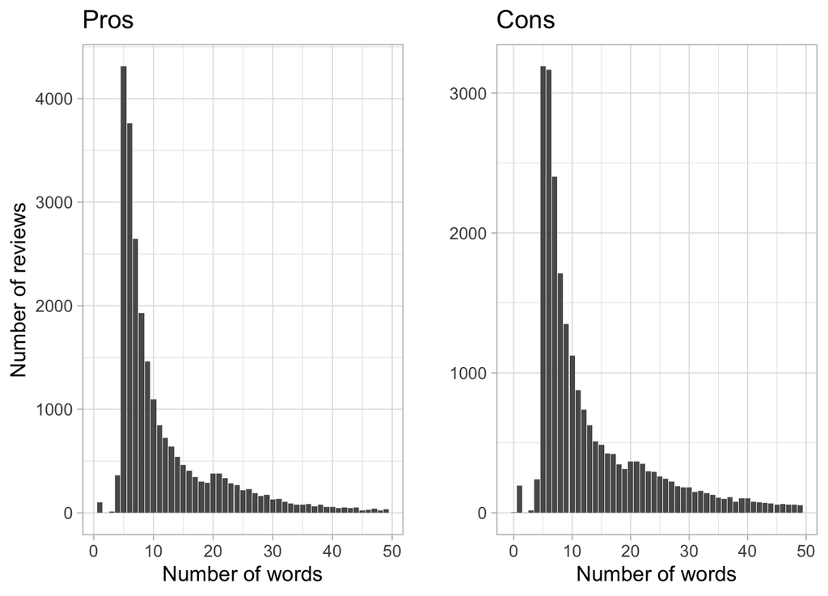

Both graphs above clearly show that the number of word per review is quite concentrated around 5-6 words. This result is not surprising, as every new Glassdoor member need to write minimum length pro and con reviews for account validation. Most of them write a very short review.

## General explorations

### Tokenization

Text Mining results are largely impacted by the tokenization process. After testing differents options, we decide to use the lemmatization as it is the most promising option.

We create the function EDA_handler, that deals with every aspect of the tokenization. The tokens are split by word and we also remove the stopwords. We also do not want to take into consideration the case and lowercase the tokens.

```
#> $Remove_stopwords_make_lemma
#> # A tibble: 150,616 x 16
#>     page review_id company review_title employee_role
#>    <dbl> <chr>     <chr>   <chr>        <chr>
#>  1     1 empRevie~ J.P. M~ Cool place   Current Empl~
#>  2     1 empRevie~ J.P. M~ Fun          Former Emplo~
#>  3     1 empRevie~ J.P. M~ Fun          Former Emplo~
#>  4     1 empRevie~ J.P. M~ Great workp~ Former Emplo~
#>  5     1 empRevie~ J.P. M~ Great workp~ Former Emplo~
#>  6     1 empRevie~ J.P. M~ Great workp~ Former Emplo~
#>  7     1 empRevie~ J.P. M~ Great workp~ Former Emplo~
#>  8     1 empRevie~ J.P. M~ Great bank   Current Empl~
#>  9     1 empRevie~ J.P. M~ Great bank   Current Empl~
#> 10     1 empRevie~ J.P. M~ Great bank   Current Empl~
#> # ... with 150,606 more rows, and 11 more variables:
#> #   employee_history <chr>, employer_cons <chr>,
#> #   employer_rating <dbl>, work_life_balance <dbl>,
#> #   culture_values <dbl>, diversity_inclusion <dbl>,
#> #   career_opportunities <dbl>, compensation_and_benefits <dbl>,
#> #   senior_management <dbl>, review_time <dttm>,
#> #   employer_pros_word <chr>
#>
#> $Most_frequent_words
#> # A tibble: 14,023 x 3
#>    company       employer_pros_word     n
#>    <chr>         <chr>              <int>
#>  1 J.P. Morgan   benefit             1388
#>  2 TD            benefit             1234
#>  3 UBS           people              1184
#>  4 Deutsche Bank people              1056
#>  5 HSBC Holdings benefit             1006
#>  6 TD            pay                  839
#>  7 J.P. Morgan   company              814
#>  8 Deutsche Bank life                 734
#>  9 Deutsche Bank balance              721
#> 10 J.P. Morgan   opportunity          719
#> # ... with 14,013 more rows
#>
#> $Plotting_most_frequent_words
#>
#> $Word_cloud
#> NULL
```

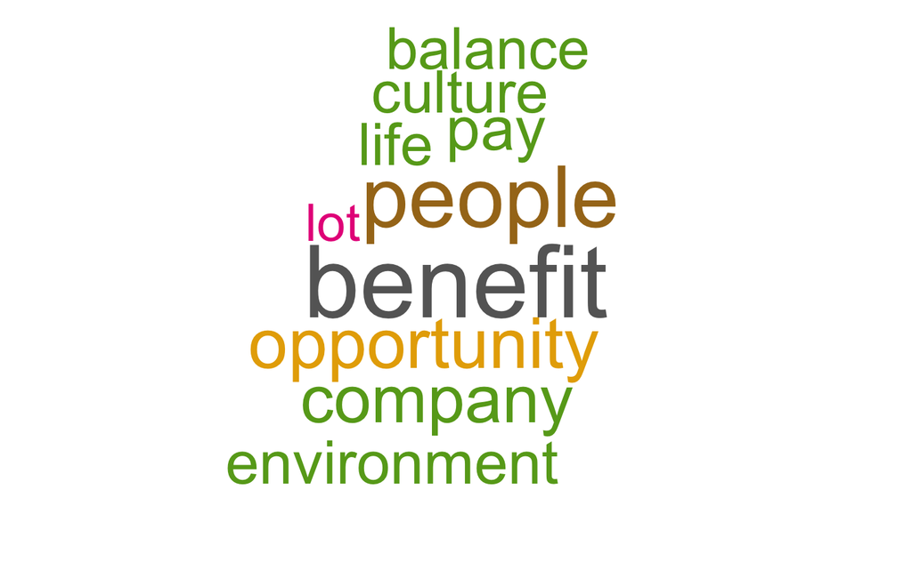

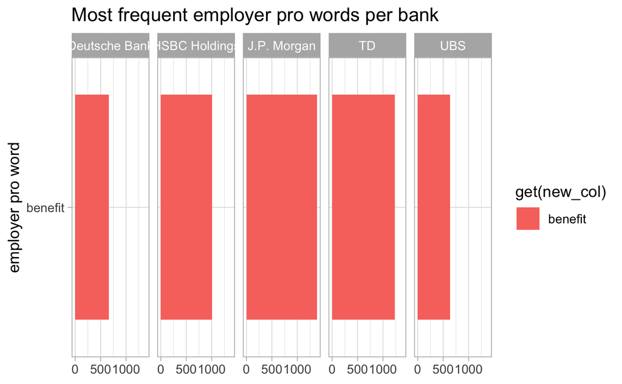

[figure not shown]

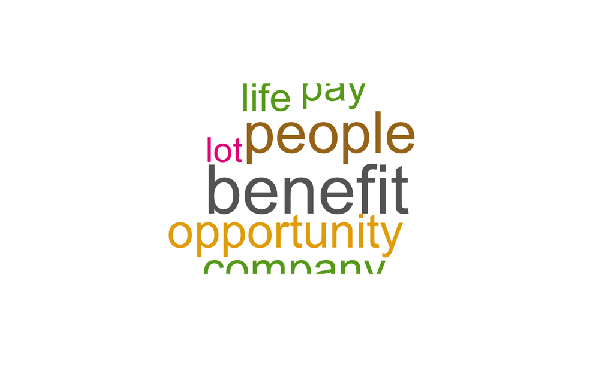

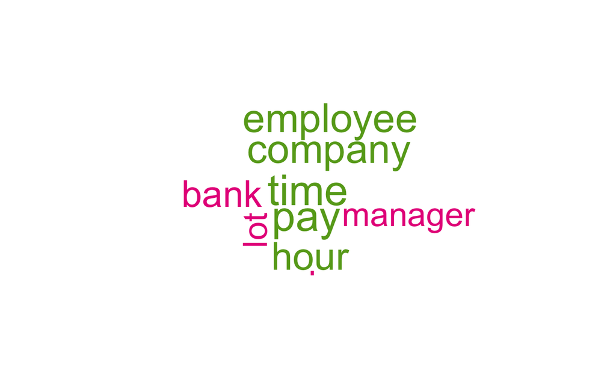

```r
# creating function to take out the pros and cons of the reviews
EDA_handler <-
  function (a_tibble,
            text_column,
            n_top = 20,
            TF_grouped = FALSE,
            TF_IDF = FALSE,
            word_cloud = FALSE,
            aggregate_cloud = FALSE,
            lemma=FALSE) {
    # creating the new column name
    new_col <- paste0(quo_name(enquo(text_column)), "_word")
    # tokenization of the reviews
    review_token <- tidytext::unnest_tokens(
      a_tibble,
      output = "word",
      input = {{text_column}},
      to_lower = TRUE,
      strip_punct = TRUE,
      strip_numeric = TRUE) %>%
      # if the lemmatization option is activated
      `if`(lemma,{.} %>% mutate(word = lemmatize_strings(word)),.) %>%
      # removing the stop words
      anti_join(., stop_words, by = "word") %>%
      rename(., !!(new_col) := "word")
    # looking at the most frequent words
    freq <- review_token %>%
      group_by(company) %>%   # grouping is also possible also with review_id
      count("{{text_column}}_word" := get(new_col), sort = TRUE) %>%
      ungroup()
    # computing the TF-IDF if the option is set as TRUE
    if (TF_IDF == TRUE) {
      reviews_TF_IDF <- tidytext::bind_tf_idf(
        tbl = freq,
        term = !!(new_col),
        document = company,
        n = n
      )
    }
    # indexing for the top n words and also if it was a TFI-IDF then use that
    # for the index instead of the the typical frequency table
    index <-
      `if`(TF_IDF, reviews_TF_IDF, freq) %>%
      `if`(TF_grouped, {.} %>% group_by(company), .) %>%
      top_n(n_top)
    # creating a function to be used for the ggplot aesthetics
    fix_lables <- function (a_column) {
      stri_replace_all_fixed(a_column, c("_", "s"), c(" ", ""), vectorize_all = FALSE)
    }
    # designing a ggplot for the most frequent words
    freq_plt <-
      `if`(TF_IDF, reviews_TF_IDF, freq) %>%
      filter(get(new_col) %in% (index %>% pull(get(new_col)))) %>%
      ggplot(aes(x = get(new_col), y = `if`(TF_IDF, tf_idf, n), fill= get(new_col))) +
      geom_col() +
      coord_flip() +
      facet_grid( ~ company) +
      theme_light() +
      # another alternative for the wrap --> facet_wrap(~company, ncol = 2)
      labs(
        title = paste0("Most frequent ",
                       fix_lables(new_col),
                       "s per bank"),
        y = `if`(TF_IDF, "TF_IDF", NULL),
        x = fix_lables(new_col)
      )

    # creating wordcloud if the option is set equal to TRUE
    if (word_cloud == TRUE) {
      set.seed(1234)
      # dev.new(width = 1000, height = 1000, unit = "px")
      #many warnings are generated on this which is normal
      if (aggregate_cloud == TRUE) {
        freq_agg <- aggregate(as.formula(paste("n", "~", new_col, sep= " "))
                              , FUN = sum, data=freq)
      }
      clouds <-
        wordcloud::wordcloud(
          words = (`if`(aggregate_cloud,freq_agg, freq) %>% pull(!!new_col)),
          freq = (`if`(aggregate_cloud,freq_agg, freq) %>% pull(n)),
          min.freq = 2,
          max.words = 10,
          random.order = FALSE,
          random.color = FALSE,
          colors = brewer.pal(8, "Dark2"))
    }

    # generating the output
    output <-
      list(
        review_token,
        # "Remove_stopwords" = review_token,
        "Most_frequent_words" = freq,
        # if(exists("clouds")){"Word_cloud" = clouds},
        "Plotting_most_frequent_words" = freq_plt
      )

    # we also add the wordcloud if available
    if(word_cloud==TRUE){
      clouds <- list("Word_cloud"=clouds)
      output <- append(output,clouds)
      }

    # changing the name of the object based on the option given
    names(output)[1] <-
      `if`(lemma,"Remove_stopwords_make_lemma","Remove_stopwords")

    return(output)
  }
```

The ggplot represents the most frequent words per company as the grouping was not done on the review but the company itself.

Regarding the pros, most often the words `benefit` and `people` come up, it is also interesting to see that the words `culture`, and `life` are also there perhaps indicating that most people care about these values when trying to describe work positively.

Also `quanteda` library could be used if needed..

### Semantic Analysis

Sentiment analysis with the two dictionaries of `nrc` and `afinn`.

```
#> # A tibble: 13,901 x 2
#>    word        sentiment
#>    <chr>       <chr>
#>  1 abacus      trust
#>  2 abandon     fear
#>  3 abandon     negative
#>  4 abandon     sadness
#>  5 abandoned   anger
#>  6 abandoned   fear
#>  7 abandoned   negative
#>  8 abandoned   sadness
#>  9 abandonment anger
#> 10 abandonment fear
#> # ... with 13,891 more rows
#> # A tibble: 2,477 x 2
#>    word       value
#>    <chr>      <dbl>
#>  1 abandon       -2
#>  2 abandoned     -2
#>  3 abandons      -2
#>  4 abducted      -2
#>  5 abduction     -2
#>  6 abductions    -2
#>  7 abhor         -3
#>  8 abhorred      -3
#>  9 abhorrent     -3
#> 10 abhors        -3
#> # ... with 2,467 more rows
```

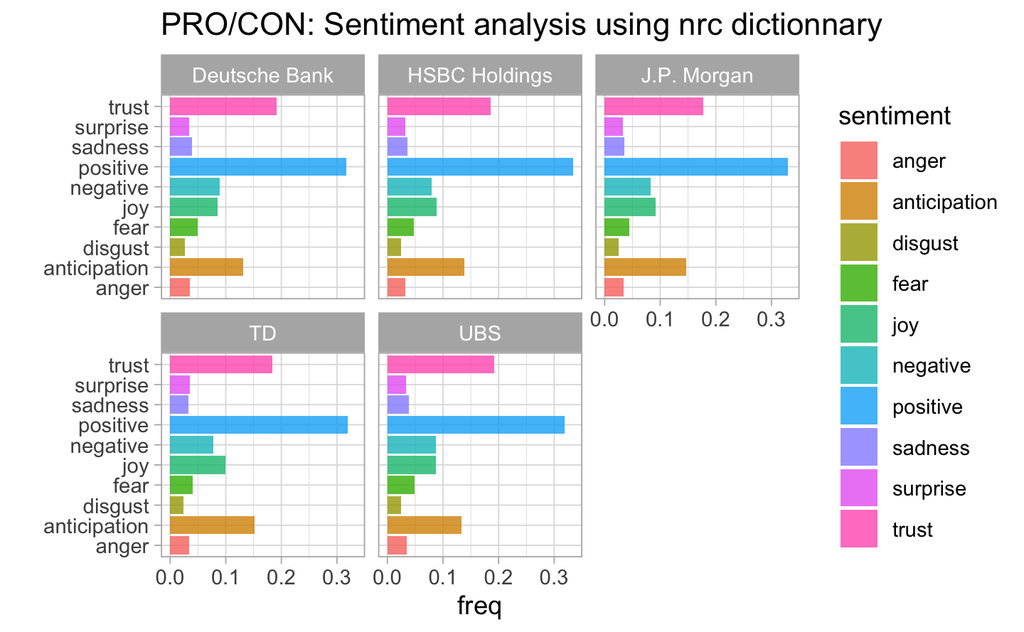

The feelings for the banks are very close to one another for the `nrc` method. Unfortunately, we won’t be able to use nrc dictionnary for classification.

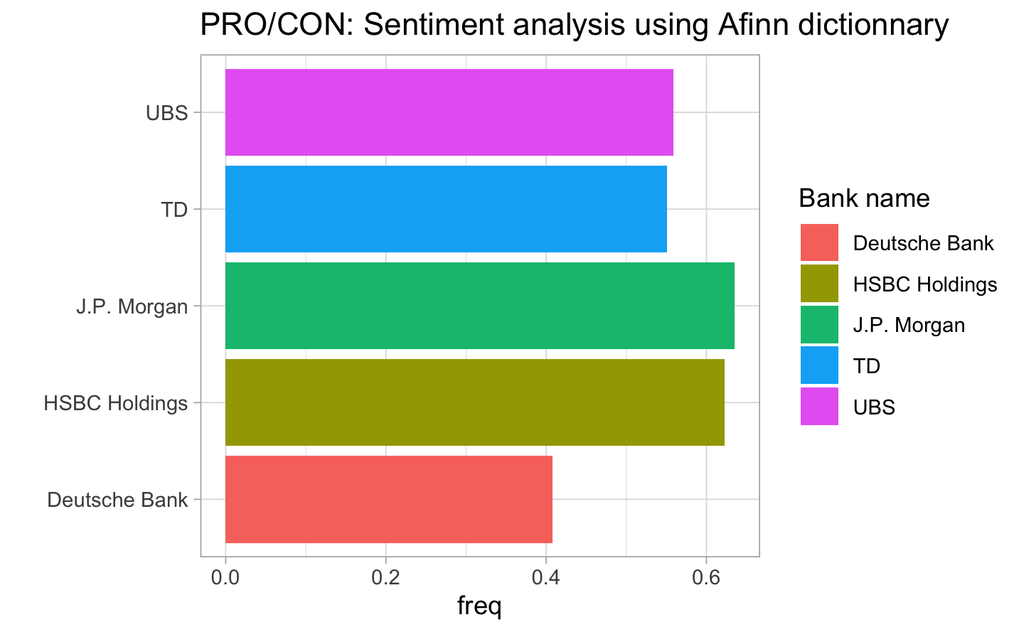

### More advanced methods with valence shifters.

Employer rating: Comparison with 2 sentiment analysis methods

| Bank name | Actual employer rating | Valence shifter score | Afinn sentiment score |
| --- | --- | --- | --- |
| J.P. Morgan | 3.77 | 0.563 | 1.162 |
| TD | 3.55 | 0.522 | 1.086 |
| HSBC Holdings | 3.53 | 0.527 | 1.237 |
| UBS | 3.45 | 0.512 | 1.212 |
| Deutsche Bank | 3.40 | 0.499 | 0.962 |

### Job positions analysis

In order to have the most accurate classifier, we need to have a look at every variable available. During the scraping process, we have also managed to extract the job position. It makes sense to have a look at it to see if the employee role has an impact on the company review score.

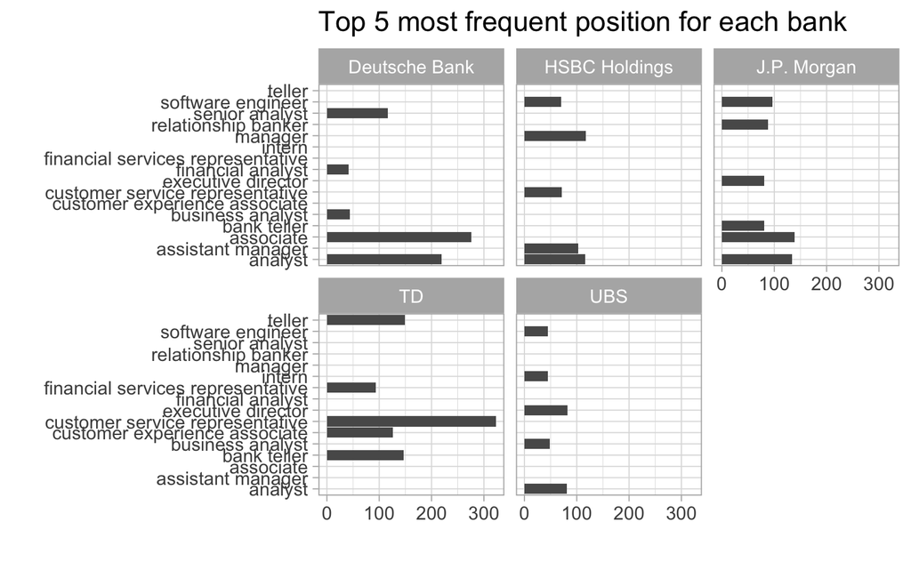

We have also explored the job positions to potentially identify patterns. After removing unaccurate job-title, we observe on the top 5 most frequent position per bank that some position seems more specific for one’s bank. For instance, UBS seems to hire a larger number of interns for its operations.

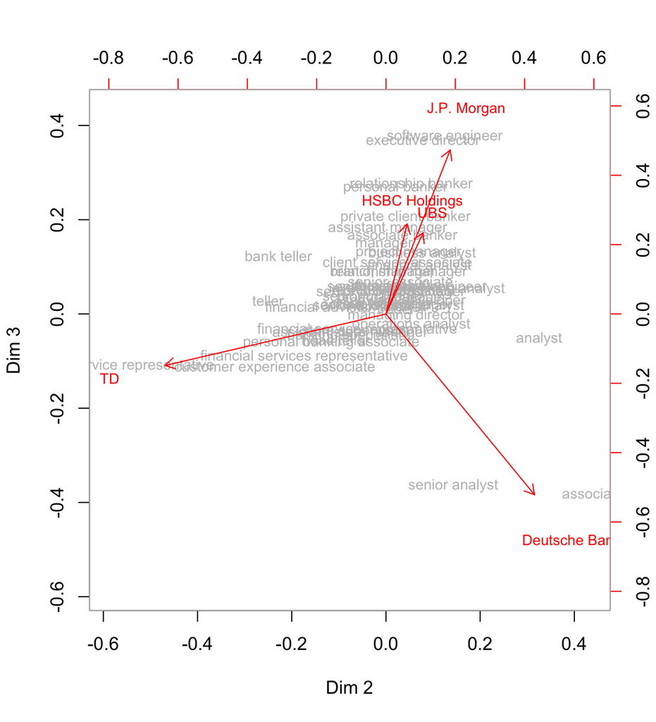

To have a more interpretable insight and using LSA techniques, we manage to biplot in 2 dimensions the top 50 job positions. Interestingly, JP Morgan, HSBC and UBS seem to have a similar job structure. On the other, TD offers more position related to representant (customer oriented), whereas DB hire more analysts.

### Compare the reviews in terms of lexical diversity

Lexical diversity can also be an interesting tool for classification. However, it seems unlikely to have a usable result here. The only expanation would be that maybe some specific banks hire many more non-english native, who english richness is lower.

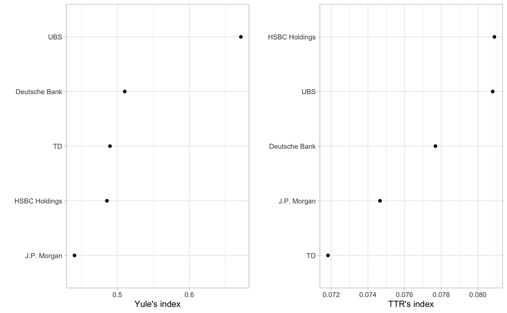

We use both Yule’s index and TTR’s index to demonstrate that they are not candidate for classification. Both graphs tell very diffferents stories, and we cannot correlate these results with the employee_review.